# 2 Bayes: the grid method

Mortality of a disease is 50% and we have 3 patients. How many of them are likely to die? We have 2 pieces of data (mortality rate p = 0.5 and N = 3) and a 4-member parameter space (0 dead, 1 dead, 2 dead, and 3 dead). We start by enumerating all logically possible scenarios (d - dead, a - alive)

d d d

d a d

d d a

a d a

a a d

a a a

a d d

d a a

Kui P(dead) = 0.5, then by simple counting we get that:

- 0 dead - 1,
- 1 dead - 3,
- 2 dead - 3,
- 3 dead - 1

Thus we have 1 + 3 + 3 + 1 = 8 possible futures that divide between the 4 hypotheses. This means that for each member of the parameter space we know the probability of its realization (P(1 death) = 3/8, etc.). It is this knowledge we now turn into a likelihood function.

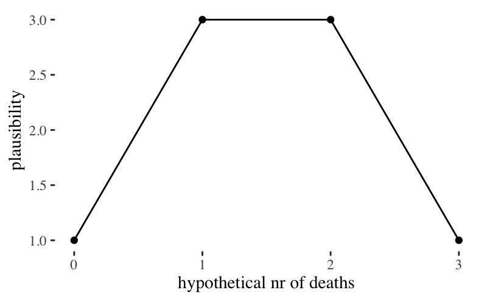

```r
# Parameter space: all possible futures
x <- seq(from = 0, to = 3)
# Likelihoods for each x value,
# or P(deaths I x)
y <- c(1, 3, 3, 1)
ggplot(data=NULL, aes(x, y)) +
  geom_point()+
  geom_line()+
  xlab("hypothetical nr of deaths")+
  ylab("plausibility")+ ggthemes::theme_tufte()
```

Yep, one death and two deaths are equilikely and one death is three times as likely as no deaths (or three deaths). Likelihood simply tells for each number of deaths, how likely is this outcome, given the mortality figure that we state.

Now we demonstrate the same using the binomial distribution model. The only difference is that now we get on the y-axis normalized probabilities.

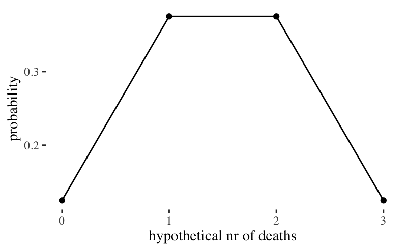

```r
y <- dbinom(x, 3, 0.5)
ggplot(data=NULL, aes(x, y)) +
  geom_point()+
  geom_line()+
  xlab("hypothetical nr of deaths")+
  ylab("probability")+ ggthemes::theme_tufte()
```

**Exercise: How about when we have 9 patients and mortality is 67%?**

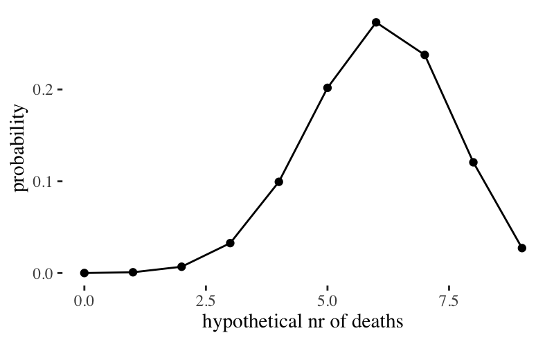

```r
x <- seq(from = 0, to = 9)
y <- dbinom(x, 9, 0.67)
ggplot(data=NULL, aes(x, y)) +
  geom_point()+
  geom_line()+
  xlab("hypothetical nr of deaths")+
  ylab("probability")+ ggthemes::theme_tufte()
```

Next we add to the likelihood a flat prior and use the Bayes theorem.

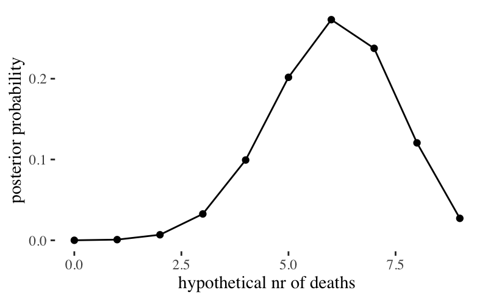

```r
x <- seq(from = 0 , to = 9) #parameter space: nr of deaths
prior <- rep(1 , 10) # flat prior
# Compute likelihood at each value in grid
likelihood <- dbinom(x, size = 9, prob = 0.67)
# Compute product of likelihood and prior
unstd.posterior <- likelihood * prior
# Normalize the posterior, so that it sums to 1
posterior <- unstd.posterior / sum(unstd.posterior)
ggplot(data = NULL, aes(x, posterior)) +
  geom_point() +
  geom_line() +
  xlab("hypothetical nr of deaths") +
  ylab("posterior probability")+ ggthemes::theme_tufte()
```

## Lets shift our problem

- data: 6 dead out of 9 patients.
- parameter to estimate: the mortality rate (p).
- parameter space: real numbers between 0 and 1.

We can still use binomial likelihood. dbinom() has 3 arguments, nr of events, nr of tries and probability of events. Again, we have two of them as data and one as the parameter whose value we want to estimate. We also use flat prior again. As there are Inf number of members in the parameter space, we cheat a little and calculate for the grid of 20 evenly spaced parameter values.

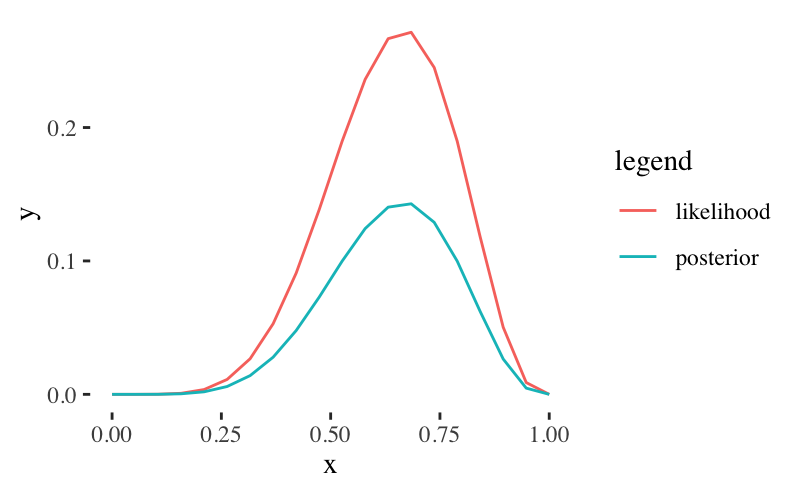

```r
# grid: mortality at 20 evenly spaced probabilities from 0 to 1
x <- seq(from = 0 , to = 1, length.out = 20)
# prior
prior <- rep(1 , 20)
# likelihood at each value in grid
likelihood <- dbinom(6, size = 9 , prob = x)
posterior <- likelihood * prior / sum(likelihood * prior)
a <- tibble(x=rep(x=x, 2),
            y= c(likelihood, posterior),
            legend= rep(c("likelihood", "posterior"), each=20))
ggplot(data=a) + geom_line(aes(x, y, color=legend))+ ggthemes::theme_tufte()
```

Our posterior sums to 1, but thanks to flat prior its shape is the same as the likelihood.

## If n = 1

N=1, 1st patient died.

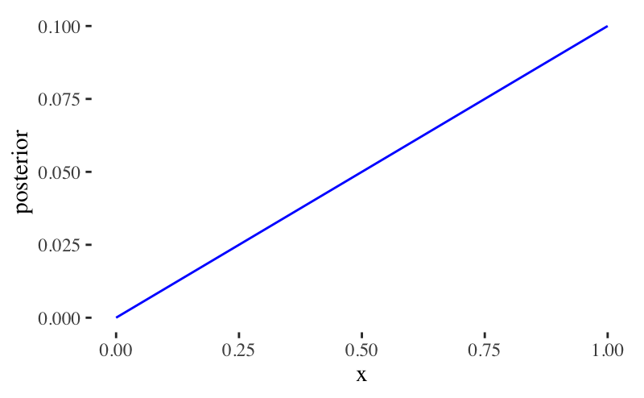

```r
prior <- rep(1, 20)
likelihood <- dbinom(1, size = 1, prob = x)
posterior <- likelihood * prior / sum(likelihood * prior)
ggplot(data=NULL)+
  geom_line(aes(x, posterior), color= "blue")+ ggthemes::theme_tufte()
```

Zero mortality is now logically impossible and 100% mortality is the hypothesis best supported by the data.

N=2, 2nd patient died. Our previous posterior is now the prior.

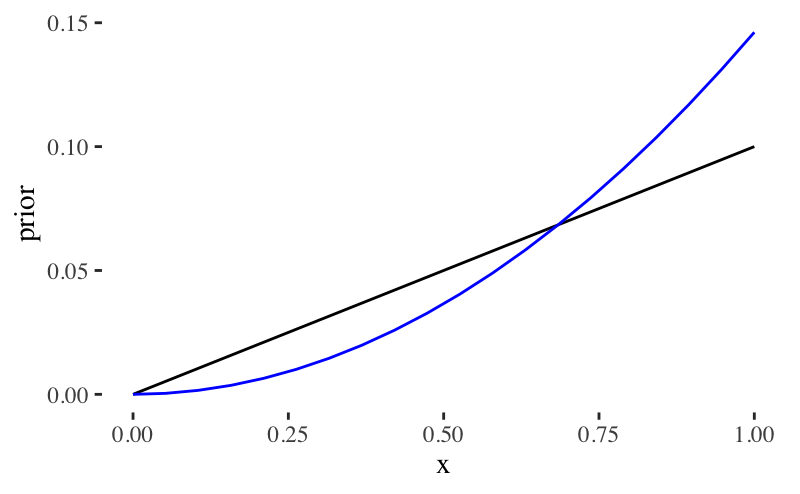

```r
prior <- posterior
likelihood <- dbinom(1 , size = 1, prob = x)
posterior1 <- likelihood * prior / sum(likelihood * prior)
ggplot(data=NULL)+
  geom_line(aes(x, prior))+
  geom_line(aes(x, posterior1), color="blue")+ ggthemes::theme_tufte()
```

The posterior is no longer a straight line. 100% mortality is still the most likely value.

N=3, 3d patient survived.

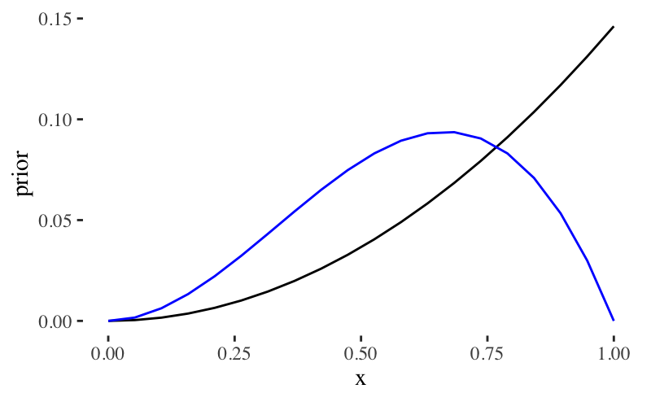

```r
prior <- posterior1
likelihood <- dbinom(0, size = 1, prob = x)
posterior2 <- likelihood * prior / sum(likelihood * prior)
ggplot(data=NULL)+
  geom_line(aes(x, prior))+
  geom_line(aes(x, posterior2), color="blue")+ ggthemes::theme_tufte()
```